```python
from PIL import Image
import numpy as np
import matplotlib.pyplot as plt
from skimage.filters import threshold_otsu, try_all_threshold, threshold_yen
import glob
import sys

from skimage import measure

from skimage.morphology import disk, square, closing, opening # for the mathematically morphology part

sys.path.append("../lab1/")
import visualPercepUtils as vpu
```

# Exercise 1

To selecet the best segmentation method I used the `try_all_threshold()` method from `skimage` to try (as its name indicates) all available thresholds.

Looking at the resulting images my first thought would be to choose something like yen to try to maximize the detected regions area. But as you can see it is not a good idea, the noise external to the regions makes it a really bad choice for applying mathematical morphology and when filling the gaps (closing) it modifies the object shapes.

My secind thought was to select the thresholds that has some equilibrium between noise inside of the object regions and outside of them. But it had the same issiues although not as pronounced as with yen.

My last thought that it was better to avoid as maximum as possible any kind of external noise to the regions, even if it meant having noise inside of them, because it can be solved filling the gaps (closing).

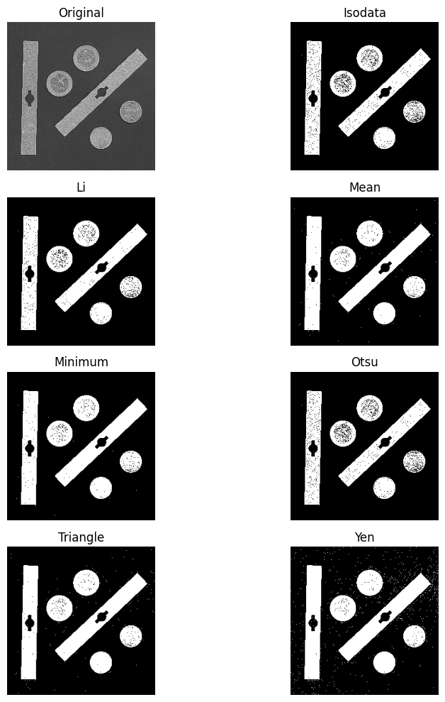

```python
im = np.array(Image.open('./imgs-P5/monedas.pgm').convert('L'))
try_all_threshold(im, figsize=(10, 10), verbose=False)
plt.show()
```

```
1 None None
```

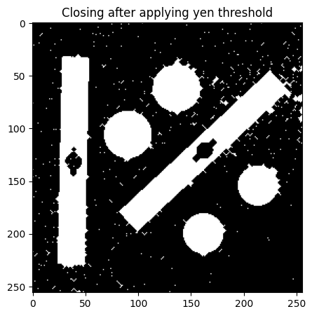

```python
binIm = im > threshold_yen(im)
sElem = disk(2)
im2 = closing(binIm, sElem)
vpu.showInGrid([im2], figure_size=(5, 5), subtitles=["Closing after applying yen threshold"])
```

# Exercise 2

I took the given methods and made some adjustments. Mainly I made it possible to adjust the disk sizes.

```python
def fillGaps(im, disk_size=1):
    binIm = im > threshold_otsu(im)
    sElem = disk(disk_size)
    return [binIm, closing(binIm, sElem)]

# Don't worry about this function
def removeSmallRegions(im, disk_size=1):
    binIm = im > threshold_otsu(im)
    sElem = disk(disk_size)
    return [binIm, opening(binIm, sElem)]

def labelConnectedComponents(im, fill_disk=1, remove_disk=1, threshold = None):
    binIm = im > threshold_otsu(im, threshold)
    binImProc = removeSmallRegions(fillGaps(im, fill_disk)[1], remove_disk)[1]
    return [binIm, binImProc,
            measure.label(binIm, background=0), measure.label(binImProc, background=0)]

def reportPropertiesRegions(labelIm,title):
    print("* * "+title)
    regions = measure.regionprops(labelIm)
    for r, region in enumerate(regions):  # enumerate() is often handy: it provides both the index and the element
        print("Region", r + 1, "(label", str(region.label) + ")")
        print("\t area: ", region.area)
        print("\t perimeter: ", round(region.perimeter, 1))  # show only one decimal place
```

This way I can get the connected components labels and easily modify disk sizes.

In the next example the best values I found for the closing and opening disks are shown.

```
1 None None
```

[output not shown]

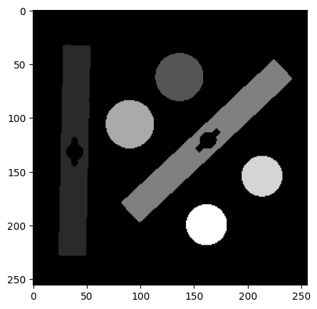

```python
vpu.showInGrid([labelConnectedComponents(im, fill_disk=2)[3]], figure_size=(5, 5))
```

Now I just get the areas and perimeters. And try to guess who is a circle. For that I calculate the radius using both, area and perimeter, and then I compare both results and if they differ in a small amount I can assure that region is a circle.

```
Number of coins: 4
```

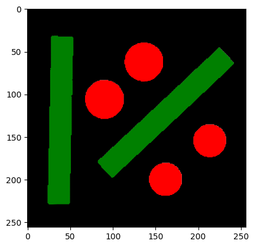

```python
labelIm = labelConnectedComponents(im, fill_disk=2)[3]
regions = measure.regionprops(labelIm)
area = np.array([r.area for r in regions])
perimeter = np.array([r.perimeter for r in regions])
coords = [r.coords for r in regions]
coins = (np.absolute((np.sqrt(area/np.pi) - perimeter/(2*np.pi)))) < 1
print("Number of coins:", coins.sum())
plt.imshow(labelIm)
for i, c in enumerate(coins):
    color="green"
    if c:
        color = "red"
    plt.plot(coords[i][:,1], coords[i][:,0], color=color)
plt.show()
```

# Exercise 3

It is essentially the same as before but if I find a cirlce just apply the proportion 50 pixels per 2,54 cm and compare. The other difference is that the coins boolean array is now a float array that gives the values of the coins: 0 for no coin, 0,1 for 10 cents coins and 1 for 1 euro coins.

```
Number of coins: 4
```

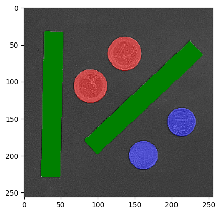

```python
labelIm = labelConnectedComponents(im, fill_disk=2)[3]
regions = measure.regionprops(labelIm)
area = np.array([r.area for r in regions])
perimeter = np.array([r.perimeter for r in regions])
coords = [r.coords for r in regions]
coins = (np.absolute((np.sqrt(area / np.pi) - perimeter / (2 * np.pi)))) < 1
print("Number of coins:", coins.sum())
coins_type = np.empty_like(coins, float)
for i, c in enumerate(coins):
    if not c:
        coins_type[i] = 0
        continue
    diameter = perimeter[i] / (np.pi) * 0.0508
    if diameter < 2.2:
        coins_type[i] = 0.10
    else:
        coins_type[i] = 1
plt.imshow(im)
for i, c in enumerate(coins_type):
    color = "green"
    alpha = 1
    if c == 1:
        color = "red"
        alpha = 0.5
    elif c == 0.1:
        color = "blue"
        alpha = 0.5
    plt.plot(coords[i][:, 1], coords[i][:, 0], color=color, alpha=alpha)
plt.show()
```

# Exercise 4

As I already computed the coins as a float array, calculating the values and amount of money is just a matter of indexing and aggregating.

```python
print("Number of coins:", coins.sum())
print("Number of 10 cents coins:", coins_type[coins_type==0.1].size)
print("Number of 1 euro coins:", coins_type[coins_type==1].size)
print("Total amount of money:", coins_type.sum())
```

```
Number of coins: 4
Number of 10 cents coins: 2
Number of 1 euro coins: 2
Total amount of money: 2.2
```